# Exploratory Data Analysis with R

Issa Abdulkadir

## Abstract

The purpose of this project is to perform exploratory data analyses on the data from the peer-to-peer personal loan service provider called Prosper. Since a borrower’s financial health is based on how many loans the borrower carries and the borrower’s ability to pay back those loans on time, Prosper uses a variety of criteria to approve personal loans- it ranges from credit score, income level, and debt-to-income ration, to name just a few. Prosper differs from the traditional lenders such as banks or other lending institutions.

The EDA encompasses mainly the branch of statistics called descriptive statistics - mean, mode, median, and standard deviation. This method is used to find the central tendency and the spread of our dataset.

This project’s EDA process is a stepping stone to learn from the historical data of personal loans. Analyzing various variables in the dataset and using statistical methods to glean insights from the dataset,can shade some light on how future borrowers can make better borrowing decisions.

## Univariate Variables

```
## [1] "data.frame"
```

```
## 'data.frame':    113937 obs. of  81 variables:
##  $ ListingKey                         : chr  "1021339766868145413AB3B" "10273602499503308B223C1" "0EE9337825851032864889A" "0EF5356002482715299901A" ...
##  $ ListingNumber                      : int  193129 1209647 81716 658116 909464 1074836 750899 768193 1023355 1023355 ...
##  $ ListingCreationDate                : chr  "2007-08-26 19:09:29.263000000" "2014-02-27 08:28:07.900000000" "2007-01-05 15:00:47.090000000" "2012-10-22 11:02:35.010000000" ...
##  $ CreditGrade                        : chr  "C" "" "HR" "" ...
##  $ Term                               : int  36 36 36 36 36 60 36 36 36 36 ...
##  $ LoanStatus                         : chr  "Completed" "Current" "Completed" "Current" ...
##  $ ClosedDate                         : chr  "2009-08-14 00:00:00" "" "2009-12-17 00:00:00" "" ...
##  $ BorrowerAPR                        : num  0.165 0.12 0.283 0.125 0.246 ...
##  $ BorrowerRate                       : num  0.158 0.092 0.275 0.0974 0.2085 ...
##  $ LenderYield                        : num  0.138 0.082 0.24 0.0874 0.1985 ...
##  $ EstimatedEffectiveYield            : num  NA 0.0796 NA 0.0849 0.1832 ...
##  $ EstimatedLoss                      : num  NA 0.0249 NA 0.0249 0.0925 ...
##  $ EstimatedReturn                    : num  NA 0.0547 NA 0.06 0.0907 ...
##  $ ProsperRating..numeric.            : int  NA 6 NA 6 3 5 2 4 7 7 ...
```

[output cut: 67 more lines]

```
##   ListingKey        ListingNumber     ListingCreationDate CreditGrade
##  Length:113937      Min.   :      4   Length:113937       Length:113937
##  Class :character   1st Qu.: 400919   Class :character    Class :character
##  Mode  :character   Median : 600554   Mode  :character    Mode  :character
##                     Mean   : 627886
##                     3rd Qu.: 892634
##                     Max.   :1255725
##
##       Term        LoanStatus         ClosedDate         BorrowerAPR
##  Min.   :12.00   Length:113937      Length:113937      Min.   :0.00653
##  1st Qu.:36.00   Class :character   Class :character   1st Qu.:0.15629
##  Median :36.00   Mode  :character   Mode  :character   Median :0.20976
##  Mean   :40.83                                         Mean   :0.21883
##  3rd Qu.:36.00                                         3rd Qu.:0.28381
##  Max.   :60.00                                         Max.   :0.51229
##                                                        NA's   :25
##   BorrowerRate     LenderYield      EstimatedEffectiveYield EstimatedLoss
##  Min.   :0.0000   Min.   :-0.0100   Min.   :-0.183          Min.   :0.005
##  1st Qu.:0.1340   1st Qu.: 0.1242   1st Qu.: 0.116          1st Qu.:0.042
##  Median :0.1840   Median : 0.1730   Median : 0.162          Median :0.072
##  Mean   :0.1928   Mean   : 0.1827   Mean   : 0.169          Mean   :0.080
##  3rd Qu.:0.2500   3rd Qu.: 0.2400   3rd Qu.: 0.224          3rd Qu.:0.112
##  Max.   :0.4975   Max.   : 0.4925   Max.   : 0.320          Max.   :0.366
##                                     NA's   :29084           NA's   :29084
##  EstimatedReturn  ProsperRating..numeric. ProsperRating..Alpha.  ProsperScore
##  Min.   :-0.183   Min.   :1.000           Length:113937         Min.   : 1.00
##  1st Qu.: 0.074   1st Qu.:3.000           Class :character      1st Qu.: 4.00
##  Median : 0.092   Median :4.000           Mode  :character      Median : 6.00
##  Mean   : 0.096   Mean   :4.072                                 Mean   : 5.95
##  3rd Qu.: 0.117   3rd Qu.:5.000                                 3rd Qu.: 8.00
##  Max.   : 0.284   Max.   :7.000                                 Max.   :11.00
##  NA's   :29084    NA's   :29084                                 NA's   :29084
##  ListingCategory..numeric. BorrowerState       Occupation
##  Min.   : 0.000            Length:113937      Length:113937
##  1st Qu.: 1.000            Class :character   Class :character
##  Median : 1.000            Mode  :character   Mode  :character
##  Mean   : 2.774
##  3rd Qu.: 3.000
##  Max.   :20.000
##
```

[output cut: 153 more lines]

```
##  Min.   :    0.00                Min.   :0.7000   Min.   : 0.00000
##  1st Qu.:    0.00                1st Qu.:1.0000   1st Qu.: 0.00000
##  Median :    0.00                Median :1.0000   Median : 0.00000
##  Mean   :   25.14                Mean   :0.9986   Mean   : 0.04803
##  3rd Qu.:    0.00                3rd Qu.:1.0000   3rd Qu.: 0.00000
##  Max.   :21117.90                Max.   :1.0125   Max.   :39.00000
##
##  InvestmentFromFriendsCount InvestmentFromFriendsAmount   Investors
##  Min.   : 0.00000           Min.   :    0.00            Min.   :   1.00
##  1st Qu.: 0.00000           1st Qu.:    0.00            1st Qu.:   2.00
##  Median : 0.00000           Median :    0.00            Median :  44.00
##  Mean   : 0.02346           Mean   :   16.55            Mean   :  80.48
##  3rd Qu.: 0.00000           3rd Qu.:    0.00            3rd Qu.: 115.00
##  Max.   :33.00000           Max.   :25000.00            Max.   :1189.00
##
```

The dataset contains 81 variables and 113,937 observations. This is a huge dataset! Let’s start with the univariate data analyses

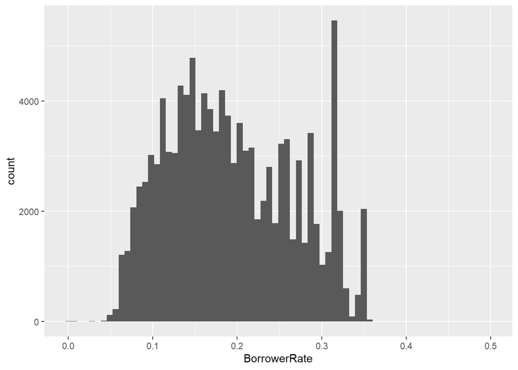

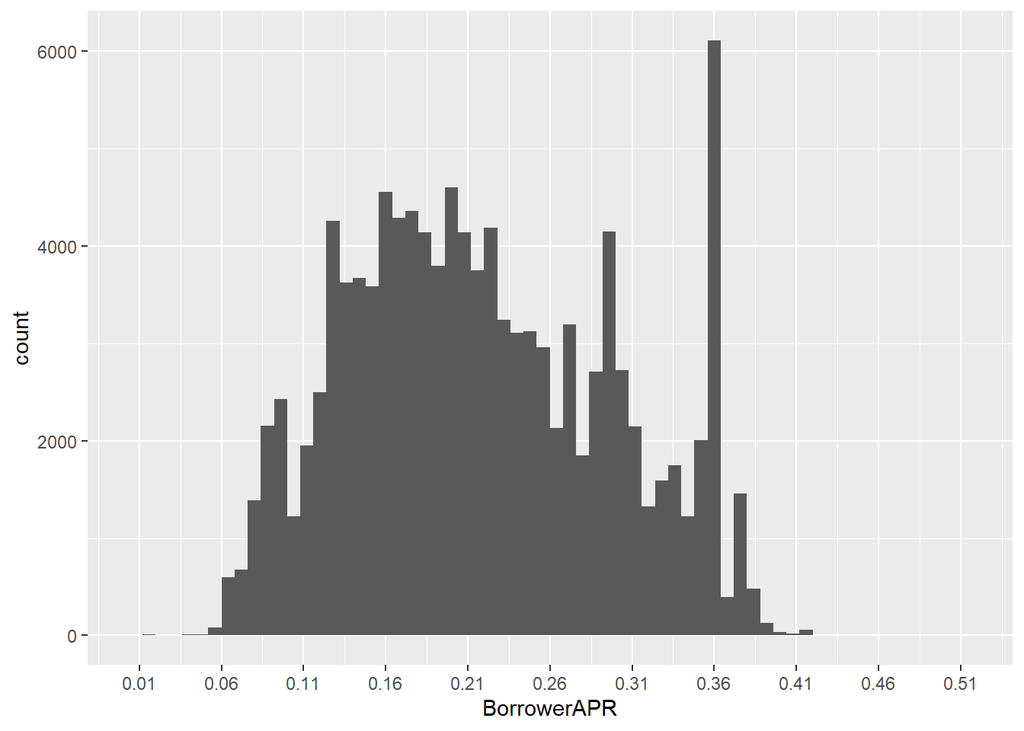

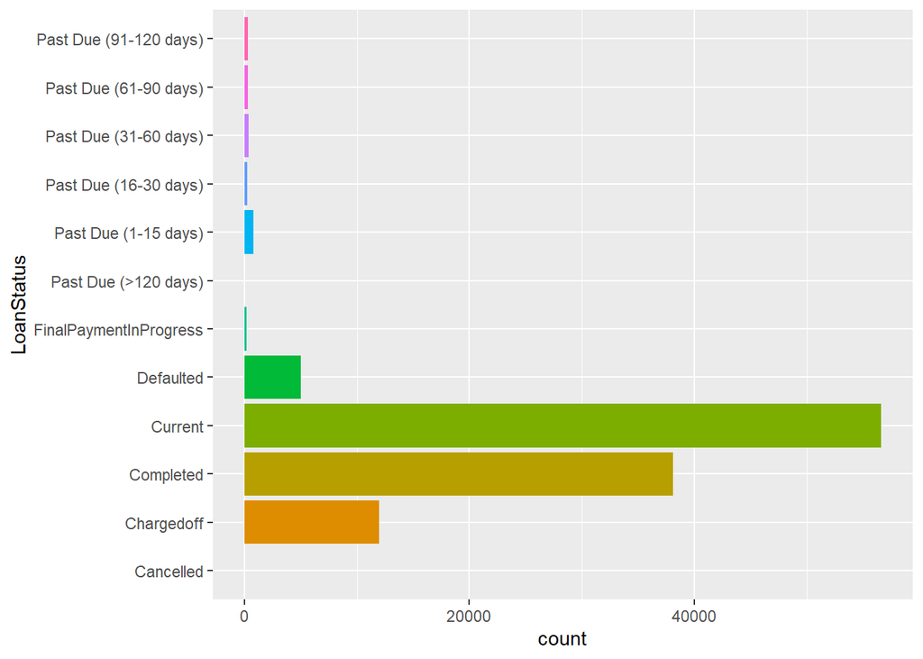

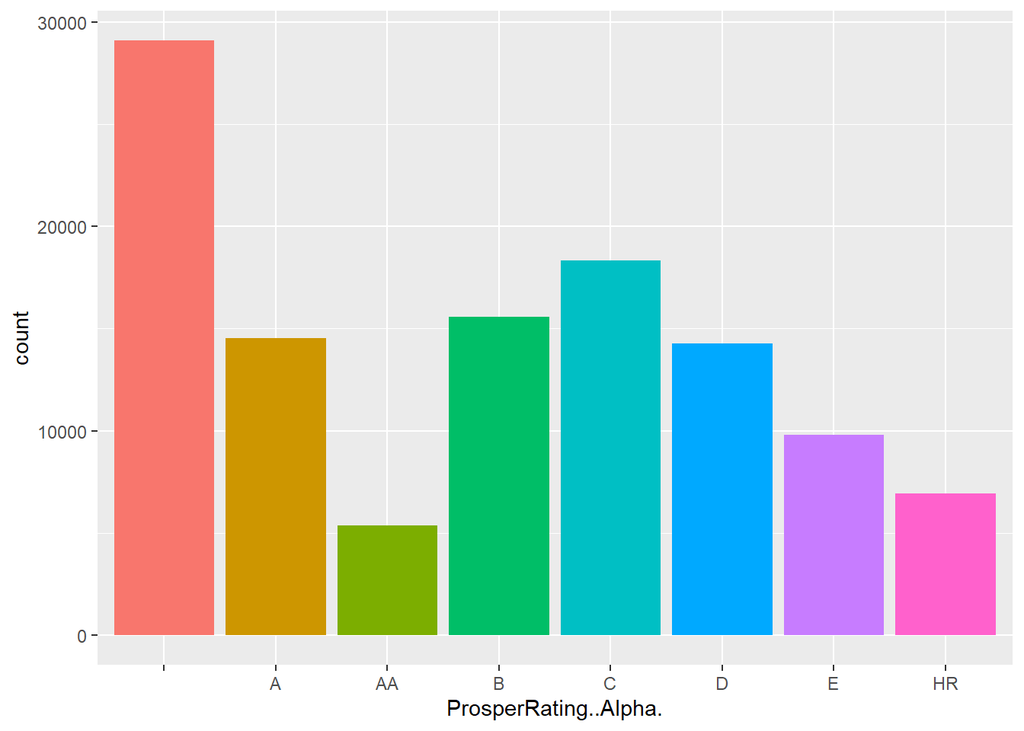

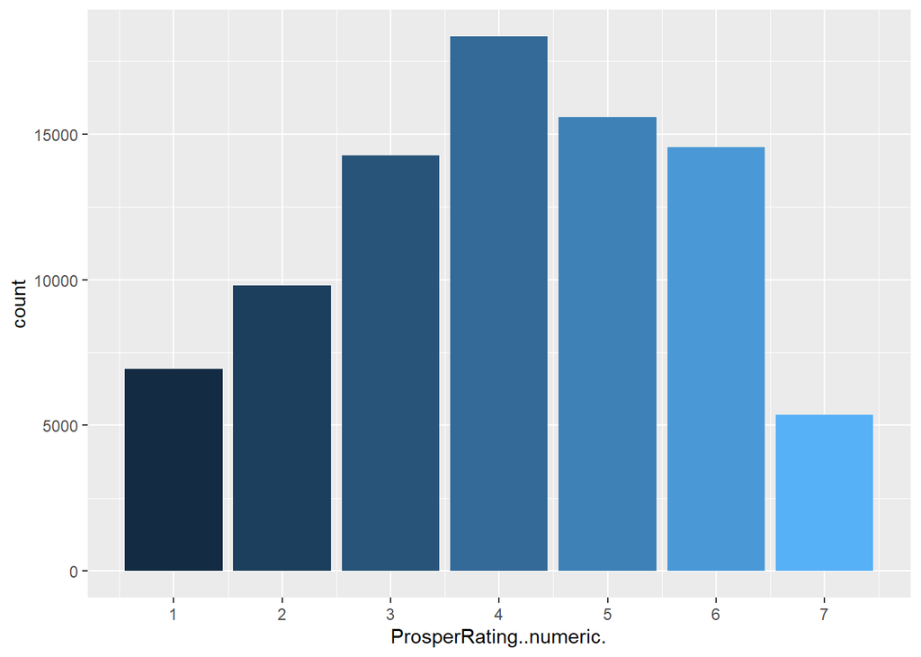

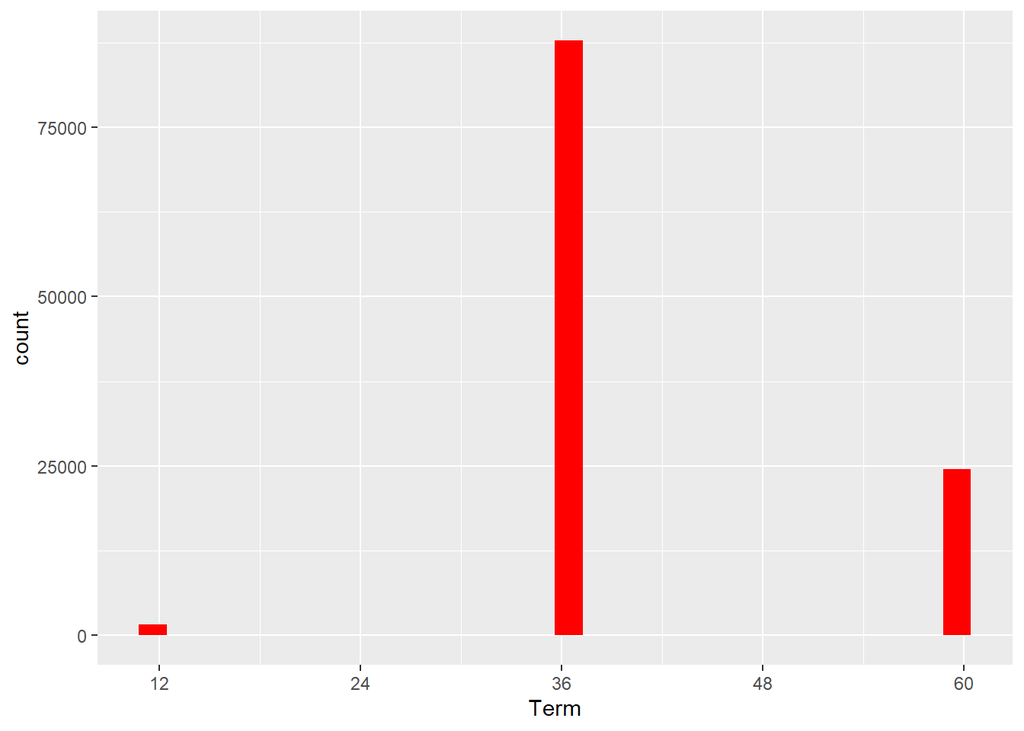

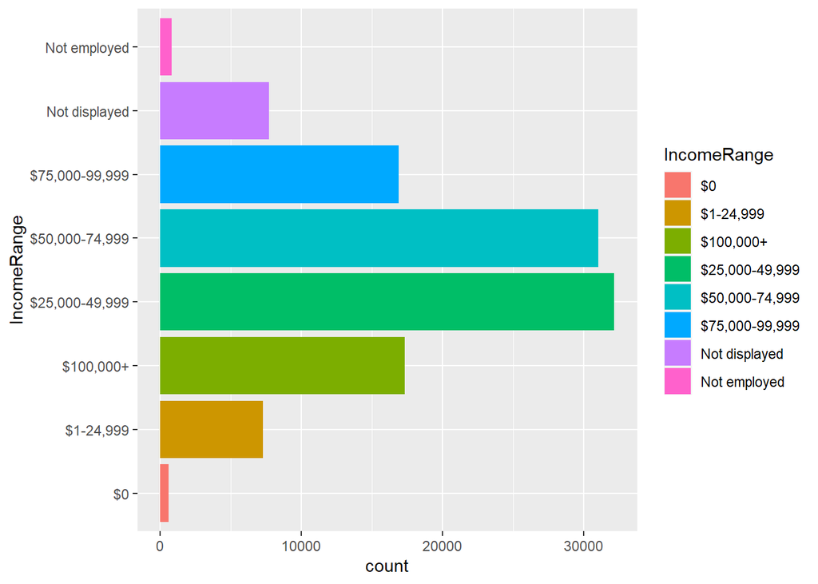

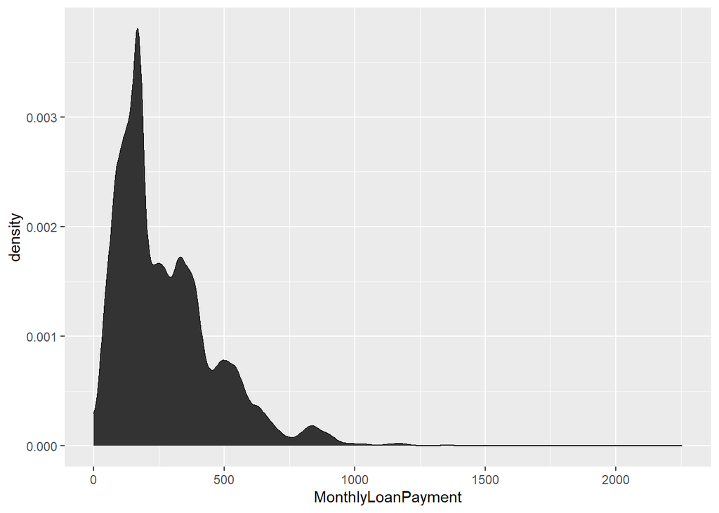

## Bivariate Analysis

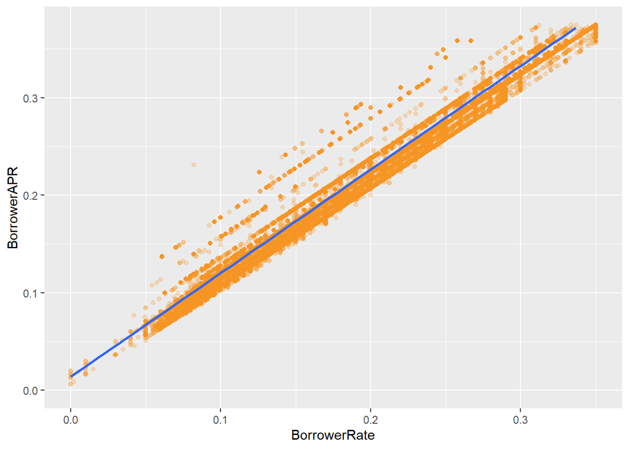

### Is there a correlation between borrowerRate and borrowerAPR?

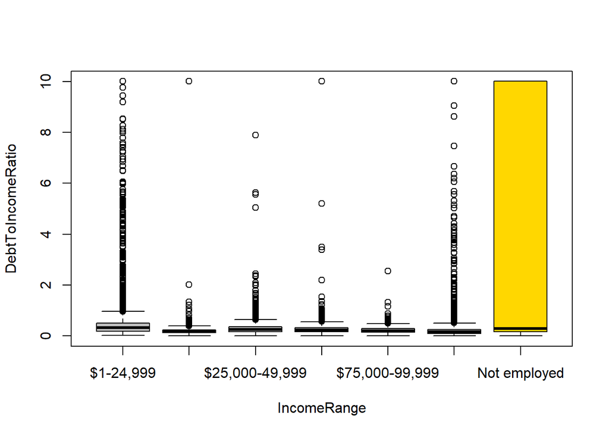

### Do the level of income and a debt a borrower has hamper a loan approval?

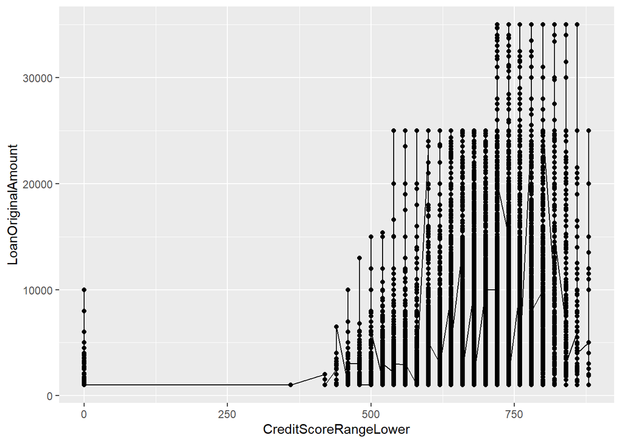

### Is it really true that a borrower must have a minimum of specified credit score to qualify for a loan?

Majority of the borrowers have credit scores greater than 500 which is a big indicator that a borrower is financially responsible. There are some outliers that indicate that a borrower does not necessary have to meet specified criteria to be granted a loan. For example, from the graph a borrower or borrowers with zero scores were able to successfully received some loans.

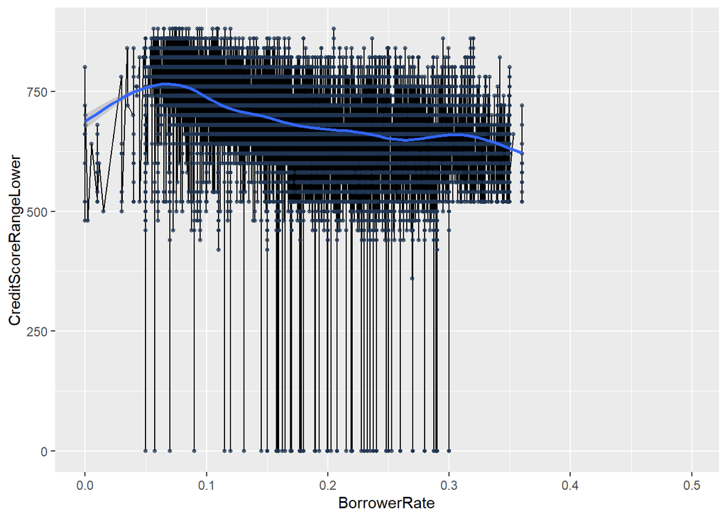

When comparing the income of the borrowers’ rate versus their credit scores, there is a trend that exhibits a higher credit score is associated with lower borrower rate and vice versa.

## Multivariate Plots

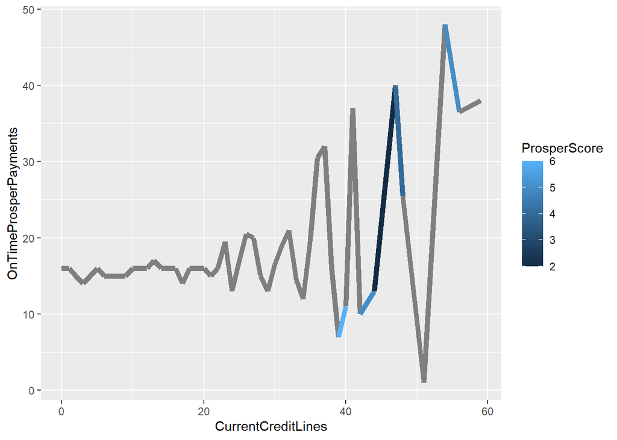

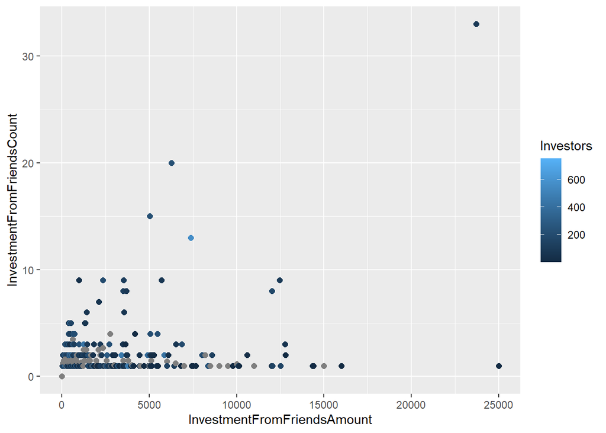

## Borrowers with Zero Delinquencies

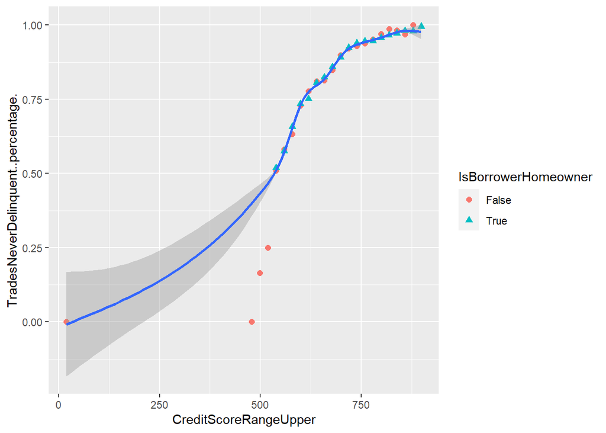

### Does owning a home indicate your are a more responsible borrower?

Through visualizing the relationship between credit score and percentage of being never delinquent on any loans, shows that borrowers with homeownership are likely to be on top of their loans as their percentage of being never delinquent is way above 50.

## Correlation of Credit Card Utilization

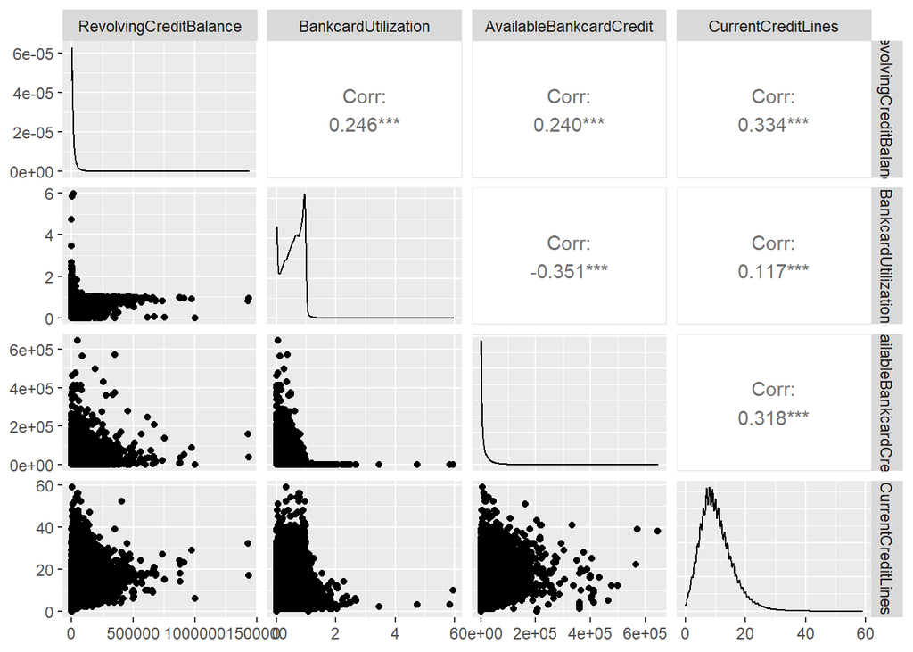

## Are there any correlations among various variables?

When plotting how borrowers use their credit cards, there is a weak correlation.

## Monthly Payments By States

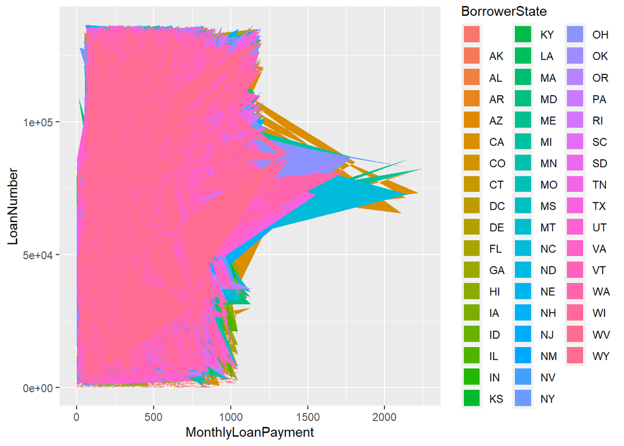

## Are borrowers in different states pay more on their monthly payments?

Apparently, most of the borrowers have payments that range from 0 to 1000 dollars while other borrowers have high monthly payments.

# Final Plots and Summary

I found three plots below very compelling in determining how borrowers’ are granted loans.

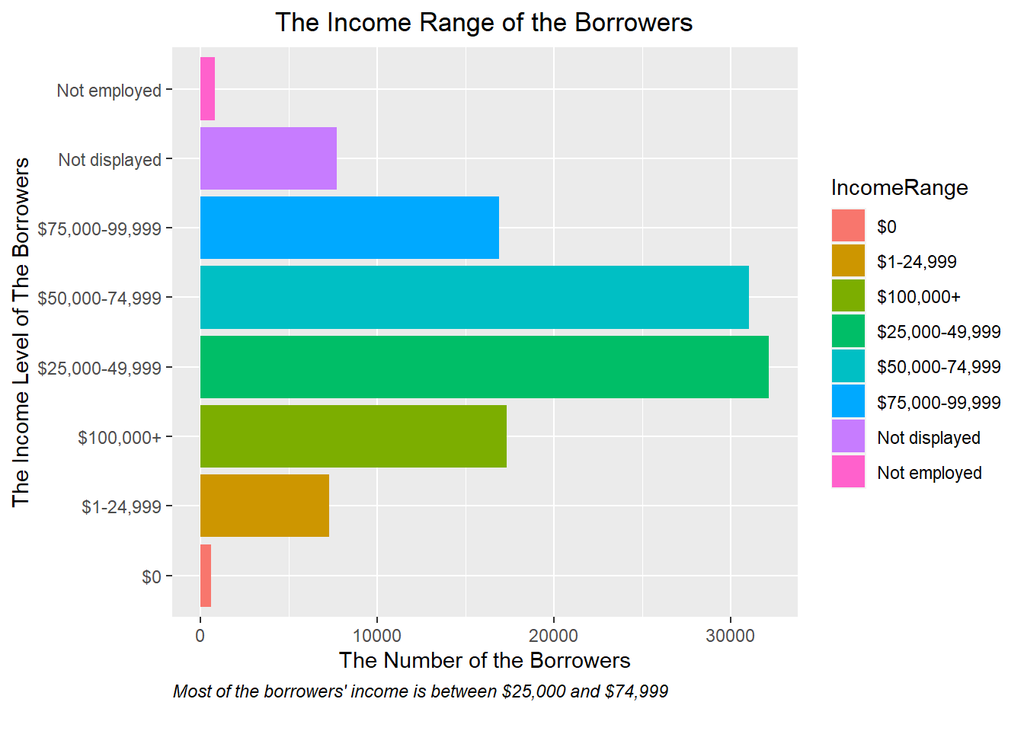

Most borrowers’ income accumulate around $25,000 to $74,999. This indicates that borrowers are likely to pay their loans back.

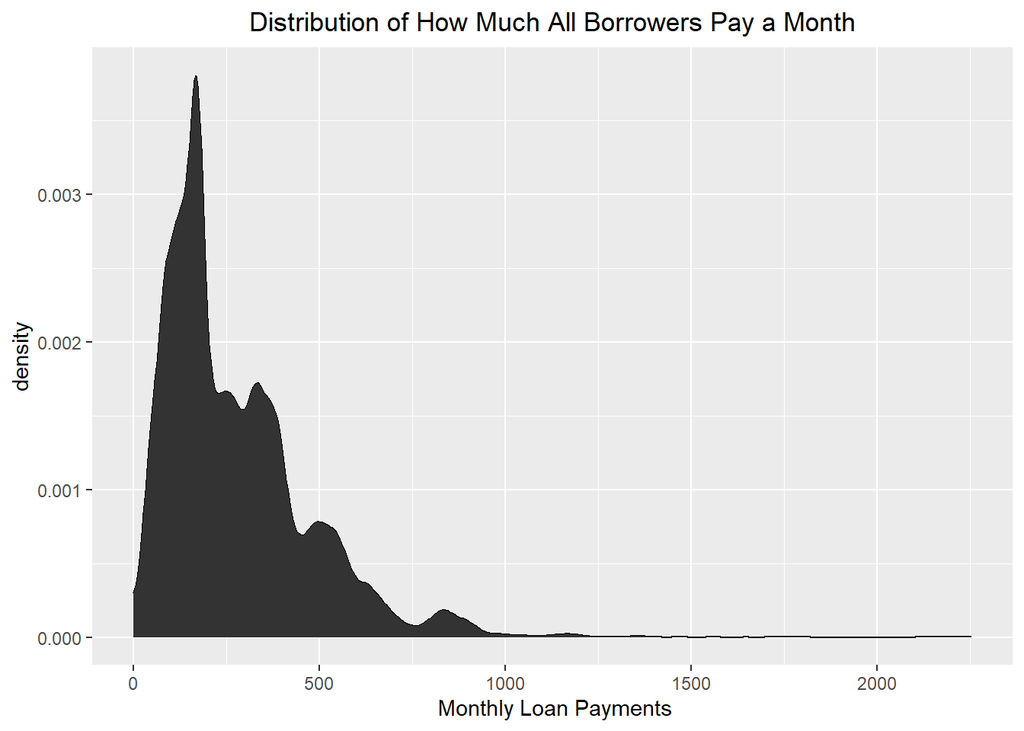

```
##    Min. 1st Qu.  Median    Mean 3rd Qu.    Max.
##     0.0   131.6   217.7   272.5   371.6  2251.5
```

The monthly payments on the loans are mostly around $200 and with the maximum payment around $2000.

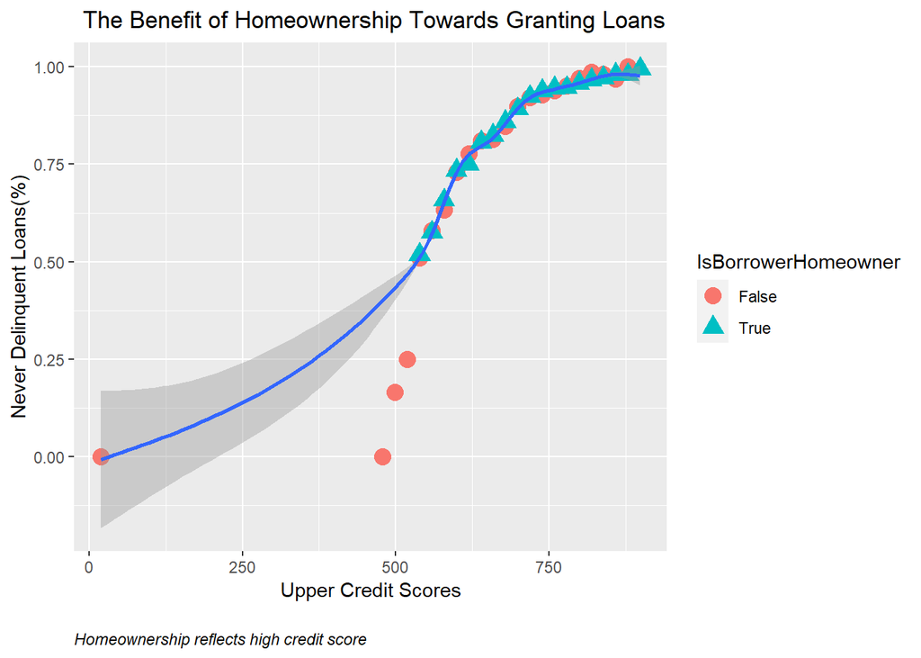

Borrowers that own homes have better credit scores and therefore less chances of being delinquent on their loans.

## Reflection

### Problems Encountered

Even though the dataset is well compiled with a few errors here and there, the missing values posed a very challenging problem in deciding how to relate various variable in graphical ways. Also, my assumption of thinking that certain values will fall within expected range was proven wrong as I came across some surprising trends in how loans are granted.

Another problem that made me frustrated is my lack of understandinng in how to plot a map using the borrowers states. I tried everything from using borrowers’ monthly loan payments and other variables in constructing a visual map of which states pay more monthly payments on the loans.

## Conclusion

Determing how to grant a loan is a very interesting and multiple-factor process. When a prospective borrower seeks a loan from a peer-to-peer lender, sometimes not all hopes are lost when the borrower’s credit history is not sound. Unlike the traditional lending institutions, lenders like Prosper take into consideration a lot of things but no one factor is proven to be a deciding factor in granting a loan.

Homeownership reflects the borrower’s ability to maintain above average credit score and which in turn helps in speeding a borrowing process from the lender.

## Sources

Black, M. (n.d.). Peer-to-Peer lending: Best websites of March 2021. Retrieved March 22, 2021, from https://www.investopedia.com/articles/investing/092315/7-best-peertopeer-lending-websites.asp